# CAP5619 - AI for FinTech

#### Spring 2023

#### Brandon Doey & Dr. Pieter De Jong

## BNPL Credit Worthiness ML application

### 1 - Problem Statement

BNPL is primarily geared toward populations with limited banking access and low credit scores. A common credit application could require a few days and the actual interaction could ward off possible borrowers. Our team wanted to investigate the feasibility of a more expeditious credit check for potential lenders and hypothesized the following: H1: Can a machine learning algorithm provide an instantaneous credit check with given user inputs? H2: Which of the applicable machine learning models has the highest accuracy?

At the time of the midterm submission, we found strong evidence in support of H1 and were able to establish that a XGBoost model (Chen & Guestrin, 2016) with given features could provide an almost instantaneous credit check for any potential borrower with 89.13% accuracy. Our goal for the final project was to find compelling evidence in support of H2 and we determined that the Keras Sequential model has an even higher accuracy score (98.07%).

Ultimately, we will be able to predict a client's creditworthiness in real time through a Gradio (Gradio, 2023) application. The client will be presented with two distinct outcomes based on their inputs at the final stage. Either they will be given a loan, or they will be referred to a web-based financial education application.

### 2 - Literature

Buy Now Pay Later (BNPL) is a kind of short-term financing that lets people pay for goods and services over time without having to worry about interest. Splitting a transaction into short-term installments is possible because BNPL does not charge interest. It may also be beneficial to merchants by making it simpler and less expensive for customers to purchase their goods. This is in addition to providing customers with flexibility and accessibility. This is especially helpful for smaller businesses that want to compete with larger retailers that offer financing options like this. BNPL can be a good option for customers who have little or no credit history because some providers do not require a credit check or a high credit score to be approved.

We used a synthetic version of the very popular "All Lending Club loan data" dataset which is roughly 400MB in size (George, n.d.) to determine creditworthiness with a machine learning application. Since the data contained all the parameters and features necessary to determine creditworthiness, we decided to utilize the same data from the midterm in the final project. The goal for the project is to provide BNPL services for underbanked populations, i.e., Generation Z and millennials. Over the past few years, digital shopping websites have become more and more popular with millennials, indicating that these customers are very familiar with digital transactions. It will be affected by the small number of customers who have not yet adopted BNPL services. Current BNPL users are more likely to use mobile phone digital wallets to buy now and pay later. Mastercard, Visa, and American Express are just a few of the major credit card issuers investing in installment solutions and developing their own BNPL applications in response.

### 3 - Modeling Type and Technique

Our project focuses on using the Keras Sequential model, a powerful deep learning technique that can accomplish various tasks such as prediction, classification, and regression, to analyze the creditworthiness of potential borrowers. The model follows a linear stack of layers, where each layer carries out a specific function on the input data and passes the results to the following layer. This adaptable architecture allows for the addition or removal of layers as needed.

To start, we prepped the data to ensure that it was in the appropriate format for input into the model. We then partitioned the data into training and validation sets and used a portion of the data to train the model. During the training phase, the model adapts its parameters to reduce the difference between the anticipated and actual outputs, thereby minimizing the error between the predicted and actual outputs.

To find the best values for different model parameters, such as the learning rate, number of epochs, and batch size, we used techniques to adjust hyperparameters. Additionally, we utilized methods to prevent overfitting, which occurs when the model is too complex and only memorizes the training data instead of learning from it.

After completing the training process, we evaluated the model's performance by assessing it on the validation set and made necessary adjustments to enhance its accuracy. Once we were satisfied with the model's performance, we deployed it to predict the creditworthiness of potential borrowers in real-time using a Gradio application.

The Sequential model considers various borrower features, including employment status, income, credit history, and other pertinent details, to make predictions about the eligibility of a potential borrower for a BNPL loan. Each layer in the model carries out a unique function to process this information, resulting in a quick and almost instantaneous credit check.

We believe that the Keras Sequential model is a robust deep learning technique that can be used for multiple tasks, including creditworthiness prediction in our project. Through our training process and fine-tuning of hyperparameters and regularization methods, we were able to achieve high accuracy in real-time predictions of borrower eligibility for BNPL loans. Our project highlights the potential of deep learning techniques for credit analysis and decision-making in financial institutions.

#### How does Keras Sequential Modeling work?

The Keras Sequential model is an implementation of a feedforward neural network (FNN) built on top of TensorFlow, where each layer in the network has a single input and a single output. These networks are known as multilayer perceptrons (MLPs) or deep FFNs.

##### Feedforward Neural Networks

Like most neural networks, FNNs consist of layers, each containing multiple neurons. However, as an FNN, Keras Sequential’s implementation of the neurons in these layers differs from traditional NNs. Each layer decreases the total number of neurons until the final output layer, which has a single neuron corresponding to the output of the model. The following is a description of the Keras sequential layers:

A standard FNN is a type of NN in which the connections between nodes do not form a loop (DeepAI, 2019). Instead, the information in a FNN moves only in one direction, from the input layer, through the hidden layers, to the output layer. This linear flow of information is why they are referred to as feedforward networks.

One of the key challenges faced by our team in the implementation of Keras Sequential is that our implementation was required to be a deep neural network, but our original trimmed data set was relatively simple. The simplicity of our data set meant that added layers for deep learning were not able to produce an increase in the accuracy of the model. By adding features back to our data set, the deep Keras sequential model was able to learn more complex relationships in the data than our ensemble model was able to achieve.

##### Activation Functions

Our implementation makes use of two activation functions.

- Rectified Linear Unit (ReLU)
  - The neurons receive a weighted sum of the input data. Neurons in the dense layers of our model apply the ReLU activation function. This function will either pass the input value itself if it is positive or pass 0 if it is negative.
  - ReLU introduces non-linearity, which helps the network model complex relationships in the data (Ramachandran et al., 2017).
- Sigmoid
  - The sigmoid activation function maps its input value to a value between 0 and 1. This function is used to produce the final output of the model.
  - Given that our problem was a binomial classification problem, sigmoid is well suited for our output.

##### Loss Function

Our model uses binary cross-entropy for its loss function. This loss function is commonly used for binomial classification problems such as our loan repayment problem (Godoy, 2022). Binary cross-entropy measures the difference between the predicted probability distribution and the true probability distribution of the binary outcome. Through this, we can account for the confidence of each prediction rather than simply accounting for the number of correct predictions.

##### Conclusion

A few challenges we came across when running our model was it took longer to train over XGBoost, especially with large datasets like taking in different demographics on loan information. This can be mitigated by using certain hardware like GPUs or TPUs which none of our classmates had the specialty tools to run it on. We did fortunately have time on our hands and the ability to fail fast using other neural network models to test our theory as well as effectiveness rates.

Neural networks in general are considered highly scalable. They can handle very large data sets. So, if new input data were to arise in our case to add more to our demographics, this would not be a challenge at all due to the fact that we have the ability to increase the number of layers within our model which in turn would increase the complexity in the relationships in the data.

The Keras model makes use of two activation functions, the ReLU function for neurons in the dense layers and the sigmoid function for the output layer. The model uses binary cross-entropy for its loss function, which measures the difference between the predicted probability distribution and the true probability distribution of the binary outcome.

Our dataset using XGBoost from our midterm was considered small, since we took another approach with our final project, we thought to add more data which we found to show a small decrease in performance with the previous model. We then did some testing on other models and concluded that Keras is better suited for tasks that are unstructured that involve images, audio, and text.

As a result, the Keras Sequential Model is a deep learning technique that can be used for various tasks, including creditworthiness prediction, as demonstrated in our final project. We put an emphasis on the importance of training and fine tuning the model to achieve the highest level of accuracy in real-time predictions of borrower eligibility for BNPL loans. We believe our project highlights the potential of deep learning techniques for credit analysis and can make a big impact within financial institutions and our everyday lives.

### 4 - Implementation

4.1 Import all packages

4.2 Read data

4.3 Create an instance of the classifier

4.4 Train the classifier

4.5 Check on the training set and visualize performance

4.6 Compute the prediction according to the model

4.7 Test and Validate

4.8 Check on the test set and visualize performance

4.9 Compute the evaluation metrics - accuracy, precision, recall, F1-score

4.10 Compute the confusion matrix - sensitivity & specificity

### 4.1 Import all packages

```python
#import all necessary packages
import os
import pandas as pd
import numpy as np
from sklearn.model_selection import train_test_split
from sklearn.preprocessing import MinMaxScaler
from sklearn.metrics import classification_report, confusion_matrix
from sklearn.metrics import accuracy_score, precision_score, recall_score, f1_score, roc_curve, roc_auc_score, confusion_matrix
from sklearn import metrics
import tensorflow as tf
from tensorflow.keras.models import Sequential
from tensorflow.keras.layers import Dense, Dropout
from tensorflow.keras.metrics import Precision, Recall
import matplotlib.pyplot as plt
import seaborn as sns
import warnings
warnings.filterwarnings('ignore')
```

[output not shown]

### 4.2 Read Data

```python
#read in the clean csv file
df = pd.read_csv('/work/loan_data_clean_dnn.csv')

# turn all columns to int type
loan_data = df.astype(int)

# drop loan_status from loan_data and assign to X
X = loan_data.drop('loan_paid', axis=1)
y = loan_data['loan_paid']


# split X and y into training and testing sets
X_train, X_test, y_train, y_test = train_test_split(X, y, test_size=0.2, random_state=42)

# Split the training set into training and validation sets
X_train, X_val, y_train, y_val = train_test_split(X_train, y_train, test_size=0.2, random_state=42)

# Print the shapes of the datasets
print('X_train shape:', X_train.shape)
print('y_train shape:', y_train.shape)
print('X_test shape:', X_test.shape)
print('y_test shape:', y_test.shape)
print('X_val shape:', X_val.shape)
print('y_val shape:', y_val.shape)
```

```
X_train shape: (361891, 81)
y_train shape: (361891,)
X_test shape: (113091, 81)
y_test shape: (113091,)
X_val shape: (90473, 81)
y_val shape: (90473,)
```

### 4.3 Create an instance of the classifier

```python
#add a scaler and verify the data
scaler = MinMaxScaler()

X_train= scaler.fit_transform(X_train)
X_test = scaler.transform(X_test)
X_val = scaler.transform(X_val)

print(X_train.shape)
print(X_test.shape)
print(X_val.shape)

model = Sequential()
model.add(Dense(units=78,activation='relu'))
model.add(Dense(units=39,activation='relu'))
model.add(Dense(units=19,activation='relu'))
model.add(Dense(units=8,activation='relu'))
model.add(Dense(units=4,activation='relu'))
model.add(Dense(units=1,activation='sigmoid'))

model.compile(loss='binary_crossentropy', optimizer='adam', metrics=['accuracy', Precision(name='precision'), Recall(name='recall')])
```

[output not shown]

### 4.4 Train the classifier

```python
#train the classifier
keras_seq = model.fit(x=X_train,
y=y_train,
epochs=40,
batch_size=512,
validation_data=(X_val, y_val), verbose=1)
```

### 4.5 Check on the training set and visualize performance

```python
# Evaluate the model on the training set
train_metrics = model.evaluate(X_train, y_train, verbose=1)

# Extract the individual metrics
train_loss, train_accuracy, train_precision, train_recall = train_metrics

# Print the metrics
print("Train loss:", train_loss)
print("Train accuracy:", train_accuracy)
print("Train precision:", train_precision)
print("Train recall:", train_recall)
```

```
Train loss: 0.0447419136762619
Train accuracy: 0.9836138486862183
Train precision: 0.9817090630531311
Train recall: 0.9834414720535278
```

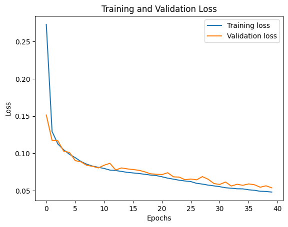

```python
# Plot the training and validation loss
plt.plot(keras_seq.history['loss'], label='Training loss')
plt.plot(keras_seq.history['val_loss'], label='Validation loss')
plt.xlabel('Epochs')
plt.ylabel('Loss')
plt.title('Training and Validation Loss')
plt.legend()
plt.show()
```

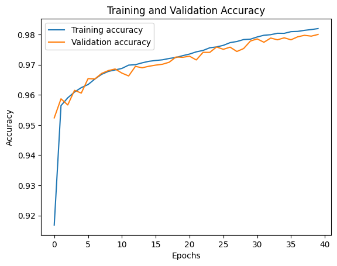

```python
# Plot the training and validation accuracy
plt.plot(keras_seq.history['accuracy'], label='Training accuracy')
plt.plot(keras_seq.history['val_accuracy'], label='Validation accuracy')
plt.xlabel('Epochs')
plt.ylabel('Accuracy')
plt.title('Training and Validation Accuracy')
plt.legend()
plt.show()
```

### 4.6 Compute the prediction according to the model

```python
# compute prediction on unseen (test) dataset
y_pred = (model.predict(X_test) > 0.5).astype("int32")
print('Training Accuracy: ', round(accuracy_score(y_test, y_pred)*100, 2), '%')
print('Training Precision: ', round(precision_score(y_test, y_pred)*100, 2), '%')
print('Training Recall: ', round(recall_score(y_test, y_pred)*100, 2), '%')
print('Training F1: ', round(f1_score(y_test, y_pred)*100, 2), '%')
print('Training ROC AUC: ', round(roc_auc_score(y_test, y_pred)*100, 2), '%')
print('Training Confusion Matrix: \n', confusion_matrix(y_test, y_pred))
```

```
Training Accuracy:  98.07 %
Training Precision:  97.9 %
Training Recall:  98.0 %
Training F1:  97.95 %
Training ROC AUC:  98.07 %
Training Confusion Matrix:
 [[58808  1119]
 [ 1063 52101]]
```

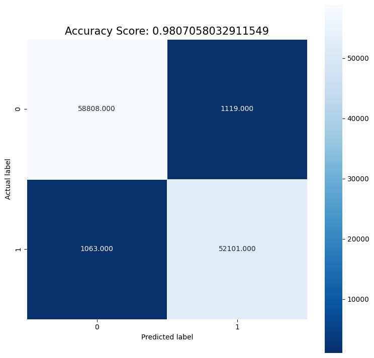

```python
# visualize the performance
cm = metrics.confusion_matrix(y_test, y_pred)
plt.figure(figsize=(9,9))
sns.heatmap(cm, annot=True, fmt=".3f", linewidths=.5, square = True, cmap = 'Blues_r');
plt.ylabel('Actual label');
plt.xlabel('Predicted label');
all_sample_title = 'Accuracy Score: {0}'.format(accuracy_score(y_test, y_pred))
plt.title(all_sample_title, size = 15);
```

```python
# make predictions on the testing set
y_pred_class = (model.predict(X_test) > 0.5).astype("int32")
pred=y_pred_class.tolist()
pred_1 = [i[0] for i in pred]
pred_2 = ''.join(str(pred_1).split(','))
# print true vs predicted

print('True:', y_test.values[0:25])
print('Pred:', pred_2[0:50])
```

```
True: [0 1 0 0 1 1 0 1 1 1 0 1 0 0 1 0 0 0 0 0 1 1 1 0 1]
Pred: [0 1 0 0 1 1 0 1 1 1 0 1 0 0 1 0 0 0 0 0 1 1 1 0 1
```

### 4.7 Test and Validate

```python
# Evaluate the model on the test set
test_metrics = model.evaluate(X_test, y_test, verbose=1)

# Extract the individual metrics
test_loss, test_accuracy, test_precision, test_recall = test_metrics

# Print the metrics
print("Test loss:", test_loss)
print("Test accuracy:", test_accuracy)
print("Test precision:", test_precision)
print("Test recall:", test_recall)
```

```
Test loss: 0.0533980056643486
Test accuracy: 0.9807057976722717
Test precision: 0.9789740443229675
Test recall: 0.9800052642822266
```

```python
y_pred_class = (model.predict(X_test) > 0.5).astype("int32")
#predictions = (model.predict(X_test) > 0.5).astype("int32")
print('Testing Accuracy score: ', round(accuracy_score(y_test, y_pred_class)*100, 2), '%')
print('Testing Precision score: ', round(precision_score(y_test, y_pred_class)*100, 2), '%')
print('Testing Recall score: ', round(recall_score(y_test, y_pred_class)*100, 2), '%')
print('Testing F1 score: ', round(f1_score(y_test, y_pred_class)*100, 2), '%')
print('Testing ROC AUC score: ', round(roc_auc_score(y_test, y_pred_class)*100, 2), '%')
print('Testing Confusion matrix: \n', confusion_matrix(y_test, y_pred_class))
```

```
Testing Accuracy score:  98.07 %
Testing Precision score:  97.9 %
Testing Recall score:  98.0 %
Testing F1 score:  97.95 %
Testing ROC AUC score:  98.07 %
Testing Confusion matrix:
 [[58808  1119]
 [ 1063 52101]]
```

### 4.8 Check on the test set and visualize performance

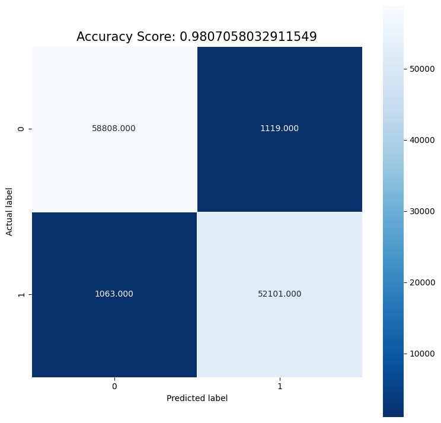

```python
# visualize the performance
cm = metrics.confusion_matrix(y_test, y_pred_class)
plt.figure(figsize=(9,9))
sns.heatmap(cm, annot=True, fmt=".3f", linewidths=.5, square = True, cmap = 'Blues_r');
plt.ylabel('Actual label');
plt.xlabel('Predicted label');
all_sample_title = 'Accuracy Score: {0}'.format(accuracy_score(y_test, y_pred_class))
plt.title(all_sample_title, size = 15);
```

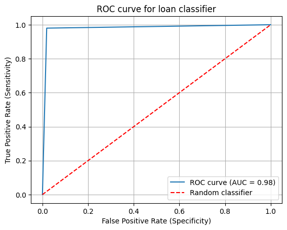

```python
# plot ROC curve
fpr, tpr, _ = roc_curve(y_test, y_pred_class)
auc = roc_auc_score(y_test, y_pred_class)

plt.figure()
plt.plot(fpr, tpr, label='ROC curve (AUC = %0.2f)' % auc)
plt.plot([0, 1], [0, 1], linestyle='--', color='r', label='Random classifier')
plt.xlabel('False Positive Rate (Specificity)')
plt.ylabel('True Positive Rate (Sensitivity)')
plt.title('ROC curve for loan classifier')
plt.legend(loc="lower right")
plt.grid(True)
plt.show()
```

### 4.9 Compute the evaluation metrics - accuracy, precision, recall, F1-score

```python
y_val_pred = (model.predict(X_val) > 0.5).astype("int32")
print('Validation accuracy score: ', round(accuracy_score(y_val, y_val_pred)*100, 2), '%')
print('Validation precision score: ', round(precision_score(y_val, y_val_pred)*100, 2), '%')
print('Validation recall score: ', round(recall_score(y_val, y_val_pred)*100, 2), '%')
print('Validation F1 score: ', round(f1_score(y_val, y_val_pred)*100, 2), '%')
print('Validation ROC AUC score: ', round(roc_auc_score(y_val, y_val_pred)*100, 2), '%')
```

```
Validation accuracy score:  98.0 %
Validation precision score:  97.78 %
Validation recall score:  98.0 %
Validation F1 score:  97.89 %
Validation ROC AUC score:  98.0 %
```

### 4.10 Compute the confusion matrix - sensitivity & specificity

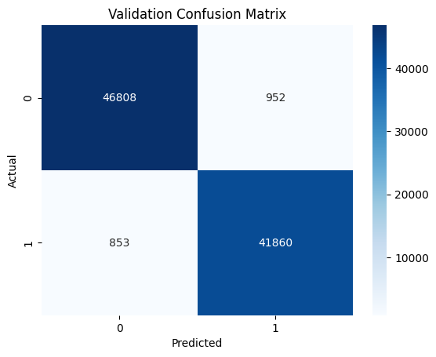

```python
# visualize the validation confusion matrix
cm = confusion_matrix(y_val, y_val_pred)
sns.heatmap(cm, annot=True, fmt='d', cmap='Blues')
plt.title('Validation Confusion Matrix')
plt.xlabel('Predicted')
plt.ylabel('Actual')
plt.show()
```

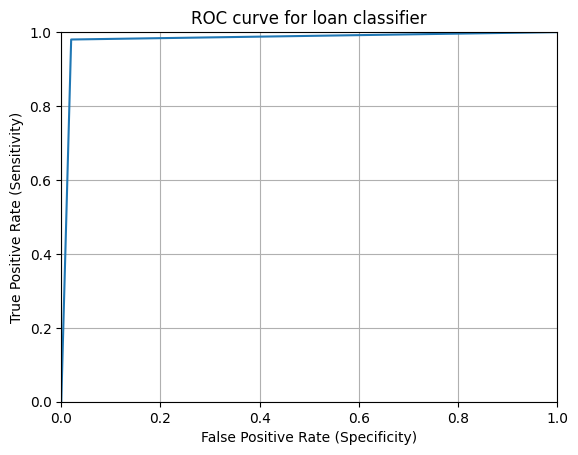

```python
# plot ROC curve
import matplotlib.pyplot as plt
fpr, tpr, thresholds = metrics.roc_curve(y_val, y_val_pred)
plt.plot(fpr, tpr)
plt.xlim([0.0, 1.0])
plt.ylim([0.0, 1.0])
plt.title('ROC curve for loan classifier')
plt.xlabel('False Positive Rate (Specificity)')
plt.ylabel('True Positive Rate (Sensitivity)')
plt.grid(True)
```

### 5 - Observations

5.1 Overview 5.2 Plot to show balanced dataset 5.3 Feature Importance 5.4 Plot Correlation Matrix 5.5 Scatterplot Open Accounts and Revolving Balance by Loan Status 5.6 Scatterplot loan size and associated late fees 5.7 Bar graph 5.8 Kernel Density Estimation Plot

### 5.1 Overview

We chose to use a synthetic dataset based on aggregated LendingClub loan data, as we did for the midterm project. This dataset was obtained from the Kaggle page located here (George, N., n.d). Unfortunately, due to the size of the dataset, we were unable to work with it easily in any online Jupyter style notebooks. As a result, we downloaded the dataset, uncompressed it, and removed a large number of columns that we deemed unnecessary. We also dropped any record whose "loan status" was anything other than "Fully Paid" (indicating the loan was paid until the balance was paid off) or "Charged Off" (indicating the borrower had failed to repay the loan). There were significantly more Fully Paid records than Charged Off records, resulting in an extremely imbalanced dataset. We knew this would have a negative impact on the accuracy of our model, so we randomly dropped Fully Paid records to bring this number down and closer to the Charged Off records (Brownlee, 2018). We were aware of other methods for manually balancing datasets, such as the Synthetic Minority Oversampling Technique (SMOTE), but due to the sheer size of the dataset, randomly removing the Fully Paid records seemed like a much simpler approach that still left us with plenty of data (over 500,000 records) to train our model on. Following the completion of these data engineering actions, a number of categorical columns were One-Hot Encoded and appended to the end of the dataset. The final step was to save the dataframe as a .csv file so that it could be saved to disk and uploaded to our Deepnote Jupyter notebook.

### 5.2 Plot to show balanced dataset

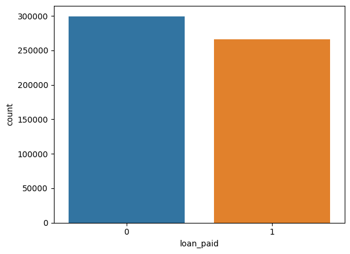

```python
# visualize the target variable in the original dataset to establish balanced dataset
sns.countplot(x='loan_paid', data=df)
plt.show()
```

### 5.3 Feature Importance

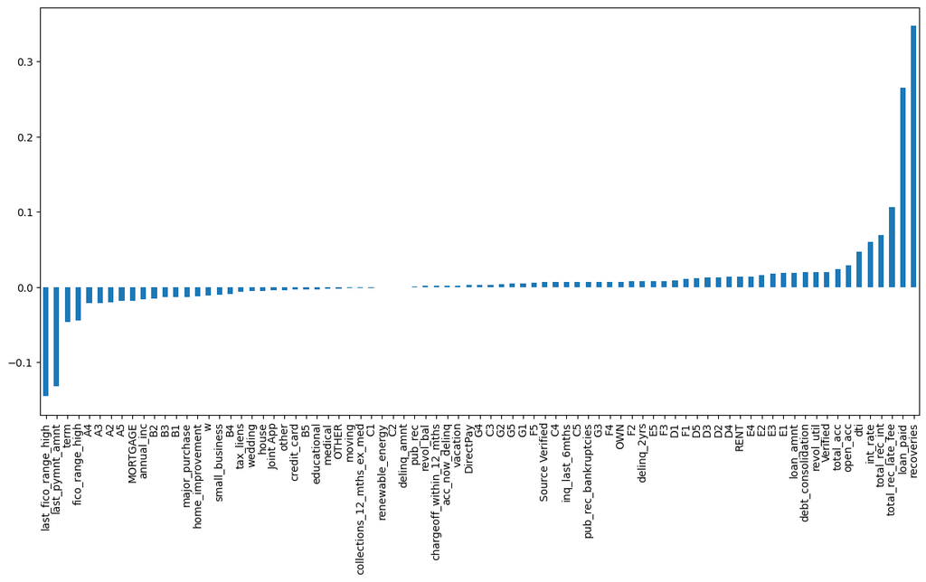

```python
# checking correlation of features to the new loan_paid column
plt.figure(figsize=(15,7))
new_corr = df.corr().iloc[:-1,-1].sort_values()
new_corr.plot.bar(rot=90)
```

### 5.4 Plot Correlation Matrix

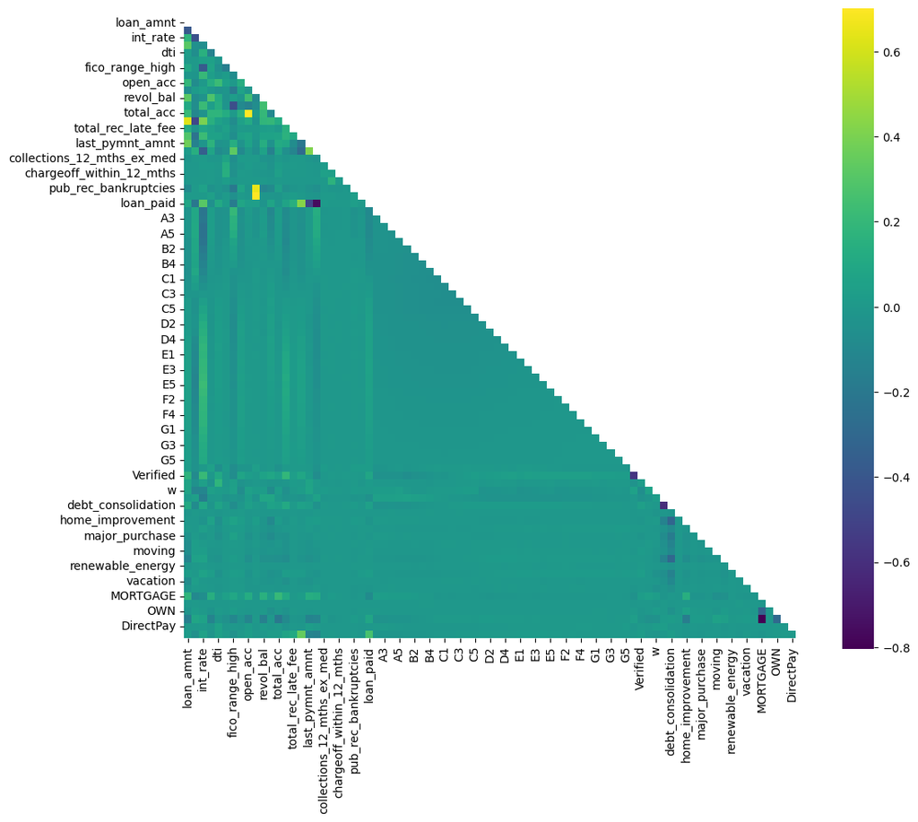

```python
# plot correlation matrix
plt.figure(figsize=(12,10))
mask = np.zeros_like(df.corr())
mask[np.triu_indices_from(mask)] = True
sns.heatmap(df.corr(), cmap='viridis', mask=mask, annot=False, square=True)
plt.show()
```

### 5.5 Scatterplot Open Accounts and Revolving Balance by Loan Status

The result of the scatter plot below shows that borrowers with fewer open accounts tend to have higher revolving balances on those accounts. This could indicate a lower credit score for these users since their total available credit would be smaller across all accounts. A high revolving balance could also mean these borrowers are overextended and may have trouble paying off their debts. The borrowers who ended up defaulting on their loans are highlighted in red below.

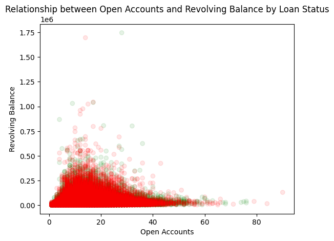

```python
# create a figure and an axis object
fig, ax = plt.subplots()
colors = {1: "green", 0: "red"}
ax.scatter(df["open_acc"], df["revol_bal"], c=df["loan_paid"].map(colors), alpha=0.1)
ax.set_xlabel("Open Accounts")
ax.set_ylabel("Revolving Balance")
ax.set_title("Relationship between Open Accounts and Revolving Balance by Loan Status")
plt.show()
```

### 5.6 Scatterplot loan size and associated late fees

The graph below may help shed light on the correlation between loan size and associated late fees. It's reasonable to assume that late fees would increase in proportion to the size of the loan, but this isn't always the case. Indeed, as can be seen below, there was a spike in late fees when the loan amount reached the $35,000 mark.

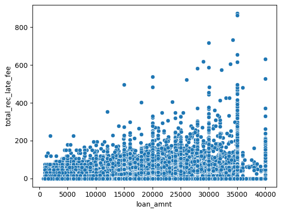

```python
# scatter plot that compares loan_amt and total_rec_late_fee
sns.scatterplot(x='loan_amnt', y='total_rec_late_fee', data=df)
plt.show()
```

### 5.7 Bar graph

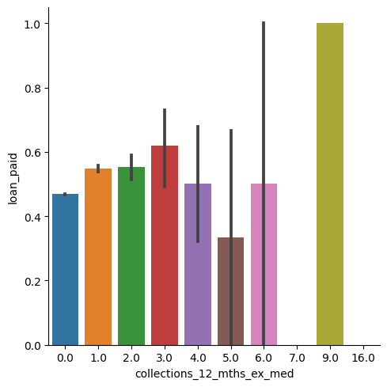

```python
# visualize the relationship between loan_paid and collections_12_mths_ex_med and group by loan_paid
sns.catplot(x='collections_12_mths_ex_med', y='loan_paid', data=df, kind='bar')
plt.show()
```

### 5.8 Kernel Density Estimation Plot

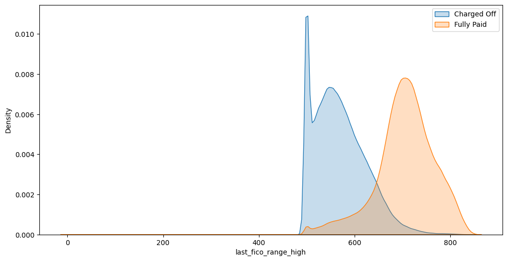

```python
# Kernel Density Estimation Plots for loan_status and last_fico_range_high and show legend
plt.figure(figsize=(12, 6))
sns.kdeplot(loan_data[loan_data['loan_paid'] == 1]['last_fico_range_high'], label='Charged Off', shade=True)
sns.kdeplot(loan_data[loan_data['loan_paid'] == 0]['last_fico_range_high'], label='Fully Paid', shade=True)
plt.xlabel('last_fico_range_high')
plt.ylabel('Density')
plt.legend()
plt.show()
```

### 6 - References

Brownlee, J. (2018, April 25). Machine Learning Mastery. Retrieved from How to Remove Outliers for Machine Learning: https://machinelearningmastery.com/how-to-use-statistics-to-identify-outliers-in-data/

Buy Now, Pay Later: Market trends and consumer impacts. (2022, September 15). Retrieved from CFBP: https://www.consumerfinance.gov/data-research/research-reports/buy-now-pay-later-market-trends-and-consumer-impacts/

DeepAI. (2019, May 17). Feed Forward Neural Network. DeepAI. Retrieved April 22, 2023, from https://deepai.org/machine-learning-glossary-and-terms/feed-forward-neural-network

George, N. (n.d.). Kaggle. Retrieved from All Lending Club loan data: https://www.kaggle.com/datasets/wordsforthewise/lending-club

Godoy, D. (2022, July 10). Understanding binary cross-entropy / log loss: A visual explanation. Medium. Retrieved April 19, 2023, from https://towardsdatascience.com/understanding-binary-cross-entropy-log-loss-a-visual-explanation-a3ac6025181a

Gradio (2023). Build & Share Delightful Machine Learning Apps. Retrieved April 23, 2023, from https://gradio.app/

Kumar, A. (2022, April). Correlation Concepts, Matrix & Heatmap using Seaborn. Retrieved from Vitalflux: https://vitalflux.com/correlation-heatmap-with-seaborn-pandas/amp/

Malhotra, V. (2020, October 12). Medium. Retrieved from ML04: Kernel Density Estimation: https://medium.com/analytics-vidhya/ml04-kernel-density-estimation-ee29a1578d0c

Ramachandran, P., Zoph, B., & Le, Q. V. (2017). Searching for activation functions. ArXiv Preprint ArXiv:1710.05941.

Team, K. (n.d.). Simple. flexible. powerful. Keras. Retrieved April 20, 2023, from https://keras.io/

[figure not shown]

Created in Deepnote